# Suicidio y climas extremos

Jaime Miguel y Lucía Toimil

# INTRODUCCIÓN

**Islandia** se caracteriza por su clima frio y extremo, además de por la escasa cantidad de luz durante gran parte del año. En cambio, **Arizona** tiene un clima cálido y seco, con abundante luz solar la mayor parte del tiempo. Estos dos lugares, con climas tan extremos y distintos, permiten evaluar de manera comparativa como diferentes condiciones climáticas pueden influir en la **salud mental** y en la tasa de **suicidios**.

# OBJETIVOS

## Objetivo general

Analizar la posible relación entre las condiciones climáticas y la salud mental, evaluando como el clima podría influir en la tasa de suicidios en Islandia y Arizona.

# Objetivos especificos

# METODOLOGÍA

## 1.1. Carga de paquetes:

A continuación se encuentran los paquetes empleados para cargar y trabajar con los datos del seminario.

```r
library(tidyverse)
library(readr)
library(lubridate)
library(rjstat)
library(jsonlite)
library(rjson)
library(tidyjson)
library(plotly)
library(dplyr)
```

## 1.2. Obtención de datos de temperatura y suicidio (Islandia y Arizona)

Para la obtencion de datos hemos realizado diversas busquedas en bases de datos y consultas a una API. El siguiente código Python define las funciones necesarias para consultar la API de Veðurstofa Íslands (api.vedur.is), buscar la estación por nombre (“Reykjav”), solicitar la temperatura media diaria (t) y guardar el resultado en archivos CSV y JSON. La consulta se ha realizado con ayuda de la IA.

```python
import requests
import pandas as pd
from datetime import datetime, date

BASE = "https://api.vedur.is/weather"
CITY_HINT = "Reykjav"              # Cambia por "Akureyri" si quieres esa zona
START = "1980-01-01"               # Puedes ampliar a 2015-01-01 cuando veas cobertura
END   = "2023-12-31"
OUT_PREFIX = "temperatura_reykjavik_2018_2023"
HEADERS = {"Accept": "application/json"}

def normalize_rows(payload):
    if isinstance(payload, list):
        return payload
    if isinstance(payload, dict) and isinstance(payload.get("data"), list):
        return payload["data"]
    if isinstance(payload, dict):
        for v in payload.values():
            if isinstance(v, list):
                return v
    return []

def find_station_id_by_name_hint(name_hint: str) -> int:
    """Busca estación por nombre en /observations/synop/latest"""
    url = f"{BASE}/observations/synop/latest"
    r = requests.get(url, params={"format":"json"}, headers=HEADERS, timeout=60)
    r.raise_for_status()
    rows = normalize_rows(r.json())
    # buscar coincidencia por nombre
    matches = [row for row in rows
               if isinstance(row, dict)
               and isinstance(row.get("name"), str)
               and name_hint.lower() in row["name"].lower()]
    if not matches:
        # Si no hay, intenta devolver la primera de la capital region (region_id=1)
        url2 = f"{BASE}/observations/synop/latest"
        r2 = requests.get(url2, params={"format":"json", "region_id":"1"}, headers=HEADERS, timeout=60)
        r2.raise_for_status()
        rows2 = normalize_rows(r2.json())
        if not rows2:
            raise RuntimeError("No pude listar estaciones (latest).")
        print("⚠ No encontré por nombre; uso primera de la región 1.")
        return int(rows2[0]["station"])
    station_id = int(matches[0]["station"])
    print(f"✔ Estación encontrada: '{matches[0]['name']}' (id={station_id})")
    return station_id

def year_chunks(start: str, end: str):
    sd = datetime.fromisoformat(start).date()
    ed = datetime.fromisoformat(end).date()
    for year in range(sd.year, ed.year + 1):
        a = date(year, 1, 1)
        b = date(year, 12, 31)
        if a < sd: a = sd
        if b > ed: b = ed
        yield a, b

def fetch_synop_agg(aggregation: str, station_id: int, day_from: date, day_to: date) -> pd.DataFrame:
    """
    Llama a /observations/synop/{aggregation} usando station_id como array en query:
    station_id=1&station_id=1  (requests admite lista de tuplas para repetir keys)
    """
    assert aggregation in {"day","month","year","clock"}
    endpoint = f"{BASE}/observations/synop/{aggregation}"
    # lista de tuplas para que 'station_id' salga repetido (array)
    params = [
        ("station_id", station_id),            # array<integer>
        ("day_from", day_from.isoformat()),
        ("day_to",   day_to.isoformat()),
        ("parameters", "basic"),
        ("format", "json"),
        ("order",  "asc"),
    ]
    r = requests.get(endpoint, params=params, headers=HEADERS, timeout=120)
    if r.status_code == 200:
        rows = normalize_rows(r.json())
        return pd.DataFrame(rows)
    # imprime ayuda de depuración
    raise RuntimeError(f"{endpoint} devolvió {r.status_code}: {r.text[:200]}")

def get_daily_t(station_id: int, start: str, end: str) -> pd.DataFrame:
    frames = []
    for a, b in year_chunks(start, end):
        try:
            df = fetch_synop_agg("day", station_id, a, b)
            if df.empty:
                print(f"⚠ Día {a}–{b}: sin filas")
                continue
            # Esperado: columns year, month, day, t (según el esquema)
            required = {"year","month","day","t"}
            if not required.issubset(df.columns):
                raise RuntimeError(f"Estructura inesperada (day). Columnas: {df.columns.tolist()}")
            df["fecha"] = pd.to_datetime(df[["year","month","day"]])
            frames.append(df[["fecha","t"]].rename(columns={"t":"temperatura_media"}).dropna())
            print(f"✔ Día {a}–{b}: {len(df)} filas")
        except Exception as e:
            print(f"❌ Día {a}–{b} error: {e}")
    if not frames:
        return pd.DataFrame(columns=["fecha","temperatura_media"])
    out = (pd.concat(frames, ignore_index=True)
             .sort_values("fecha").reset_index(drop=True))
    return out

def get_monthly_t(station_id: int, start: str, end: str) -> pd.DataFrame:
    frames = []
    for a, b in year_chunks(start, end):
        try:
            df = fetch_synop_agg("month", station_id, a, b)
            if df.empty:
                print(f"⚠ Mes {a}–{b}: sin filas")
                continue
            required = {"year","month","t"}
            if not required.issubset(df.columns):
                raise RuntimeError(f"Estructura inesperada (month). Columnas: {df.columns.tolist()}")
            # para mensual no hay 'day'; ponemos día 1
            df["fecha"] = pd.to_datetime(df[["year","month"]].assign(day=1))
            frames.append(df[["fecha","t"]].rename(columns={"t":"temperatura_media"}).dropna())
            print(f"✔ Mes {a}–{b}: {len(df)} filas")
        except Exception as e:
            print(f"❌ Mes {a}–{b} error: {e}")
    if not frames:
        return pd.DataFrame(columns=["fecha","temperatura_media"])
    out = (pd.concat(frames, ignore_index=True)
             .sort_values("fecha").reset_index(drop=True))
    return out

def save(df: pd.DataFrame, prefix: str):
    df.to_csv(f"{prefix}.csv", index=False, encoding="utf-8")
    df.to_json(f"{prefix}.json", orient="records", indent=2, date_format="iso")
    print("\n✅ Guardado en:")
    print(f" - {prefix}.csv")
    print(f" - {prefix}.json")

if __name__ == "__main__":
    station_id = find_station_id_by_name_hint(CITY_HINT)

    # 1) Intento diario
    daily = get_daily_t(station_id, START, END)

    if not daily.empty:
        print(daily.head())
        save(daily, OUT_PREFIX)                      # salida diaria
    else:
        print("↩️ No hubo datos diarios; paso a semanal (re-muestreo) o mensual.")
        # 2a) Intento semanal a partir de 'clock' o 'day' => si no hay 'day', usa 'month'
        monthly = get_monthly_t(station_id, START, END)
        if monthly.empty:
            raise SystemExit("❌ No hubo datos diarios ni mensuales en el rango. Prueba otra estación o rango.")
        save(monthly, OUT_PREFIX + "_mensual")
        print("ℹ He guardado la serie mensual. Si quieres, te genero semanal a partir de la mensual.")
```

### 1.2.1 Importacion de datos de temperatura:

#### Arizona:

Obtenemos los datos de temperatura de Arizona, desde un archivo .csv y desde un archivo .json:

```r
# Importacion datos temperatura Arizona .json
Arizona_temp_json <- fromJSON(file = "INPUT/DATA/Arizona/Temperatura/data.json")
Arizona_temp_json %>%
  spread_all() #%>%
```

```
## # A tbl_json: 2 x 1,572 tibble with a "JSON" attribute
##   ..JSON    document.id title units `189501.value` `189502.value` `189503.value`
##   <chr>           <int> <chr> <chr>          <dbl>          <dbl>          <dbl>
## 1 "{\"titl…           1 Ariz… Degr…           NA             NA               NA
## 2 "{\"1895…           2 <NA>  <NA>            40.4           43.5             50
## # ℹ 1,565 more variables: `189504.value` <dbl>, `189505.value` <dbl>,
## #   `189506.value` <dbl>, `189507.value` <dbl>, `189508.value` <dbl>,
## #   `189509.value` <dbl>, `189510.value` <dbl>, `189511.value` <dbl>,
## #   `189512.value` <dbl>, `189601.value` <dbl>, `189602.value` <dbl>,
## #   `189603.value` <dbl>, `189604.value` <dbl>, `189605.value` <dbl>,
## #   `189606.value` <dbl>, `189607.value` <dbl>, `189608.value` <dbl>,
## #   `189609.value` <dbl>, `189610.value` <dbl>, `189611.value` <dbl>, …
```

```r
  #View()

# Importacion .csv datos temperatura Arizona
Arizona_temp_csv <- read_delim(file="INPUT/DATA/Arizona/Temperatura/data.csv", delim = ",")
#View(Arizona_temp_csv)
```

Aunque disponemos de los datos de temperatura en ambos formatos, optaremos por utilizar el archivo .csv, ya que es más sencillo de manejar y el formato .json nos ha generado problemas.

#### Islandia:

Importacion de los datos de temperatura de Islandia (Reikiavik) en .json, en el periodo del 2018-2023:

```r
# Importacion datos temperatura Islandia .json
Islandia_temp_json <- fromJSON(file = "INPUT/DATA/Islandia/Temperatura/temperatura_reykjavik_2018_2023.json")
Islandia_temp_json %>%
  spread_all() #%>%
```

```
## # A tbl_json: 2,191 x 4 tibble with a "JSON" attribute
##    ..JSON                  document.id fecha                   temperatura_media
##    <chr>                         <int> <chr>                               <dbl>
##  1 "{\"fecha\":\"2018-..."           1 2018-01-01T00:00:00.000              -5.2
##  2 "{\"fecha\":\"2018-..."           2 2018-01-02T00:00:00.000              -0.2
##  3 "{\"fecha\":\"2018-..."           3 2018-01-03T00:00:00.000              -1.8
##  4 "{\"fecha\":\"2018-..."           4 2018-01-04T00:00:00.000              -0.9
##  5 "{\"fecha\":\"2018-..."           5 2018-01-05T00:00:00.000              -1.5
##  6 "{\"fecha\":\"2018-..."           6 2018-01-06T00:00:00.000               0.9
##  7 "{\"fecha\":\"2018-..."           7 2018-01-07T00:00:00.000               3.3
##  8 "{\"fecha\":\"2018-..."           8 2018-01-08T00:00:00.000               3.1
##  9 "{\"fecha\":\"2018-..."           9 2018-01-09T00:00:00.000               5.4
## 10 "{\"fecha\":\"2018-..."          10 2018-01-10T00:00:00.000               2.5
## # ℹ 2,181 more rows
```

```r
  #View()
```

### 1.2.2. Importacion de datos de suicidios:

#### Arizona:

Importamos los datos de suicidios de Arizona (relacionados con salud mental) desde un archivo CSV. Se especifican los nombres de las columnas y se salta la fila de encabezado que nos genera problemas en la importación.

```r
datos <- read_delim(
  "INPUT/DATA/Arizona/Salud/Arizona_condado_edad.csv",
  delim = "\n",  # Leer línea por línea
  col_names = FALSE,
  show_col_types = FALSE
)

# Separar y limpiar
Arizona <- datos %>%
  mutate(linea = .[[1]]) %>%
  separate(linea,
           into = c("County", "Sex", "Age_Group", "2015", "2016",
                    "2017", "2018", "2019", "2020", "2021", "2022", "2023"),
           sep = ',(?=(?:[^"]*"[^"]*")*[^"]*$)',  # Separar por comas fuera de comillas
           extra = "merge") %>%
  mutate(across(everything(), ~str_replace_all(., '"', ''))) %>%  # Quitar comillas
  select(-1) %>%  # Eliminar la primera columna original
  slice(-1)  # Eliminar la fila de encabezados si quedó duplicada

# Convertir años a numérico
Arizona <- Arizona %>%
  mutate(across(`2015`:`2023`, ~as.numeric(.)))
# Ver resultado
#View(Arizona)
```

Otro archivo .csv para complementar los datos de suicidios de Arizona desde el 2018-2023 (se utilizo la ayuda de la IA para poder importar el archivo correctamente ya que contenia los datos encapsulados con dobles comillas y más caracteres que dificultaban su procesamiento):

```r
# Importacion .csv datos suicidios de Arizona (relacionado con salud mental)
datos2 <- read.csv("INPUT/DATA/Arizona/Salud/reports-data-export.csv",
                   header = TRUE,
                   stringsAsFactors = FALSE)

# Usar una expresión regular más sofisticada para separar respetando las comillas
datos_separados <- datos2 %>%
  mutate(linea = .[[1]]) %>%
  separate(linea,
           into = c("Intent", "Year", "Age_Group", "Sex", "Deaths",
                    "Population", "Crude_Rate", "Age_Adjusted_Rate",
                    "Years_Potential_Life_Lost"),
           sep = ',(?=(?:[^"]*"[^"]*")*[^"]*$)',  # Separar por comas fuera de comillas
           extra = "merge") %>%
  mutate(across(everything(), ~str_replace_all(., '"', ''))) %>%  # Quitar comillas
  select(-1)  # Eliminar la primera columna original

# Ver resultado
#View(datos_separados)
```

#### Islandia:

Importamos los datos de suicidios de Islandia desde un archivo JSON con formato JSON-stat.

```r
# Importacion .json datos suicidios de Islandia (relacionado con salud mental)
Islandia_suicidio_json <- fromJSONstat("INPUT/DATA/Islandia/Salud/suicidios_islandia.json")
df <- as.data.frame(Islandia_suicidio_json)
#View(df)
```

## 1.3. Limpieza y preparación de datos

```r
Arizona_temp_filtrado <- Arizona_temp_csv %>%
  filter(Date >= 201801 & Date <= 202312) %>%
  mutate(
    Year = Date %/% 100,
    Month = Date %% 100,
    Value = round((Value - 32) * 5/9, 1)
  ) %>%
  select(Year, Month, Value)

#View(Arizona_temp_filtrado)
```

#### Islandia:

En el caso de Islandia , los datos ya están filtrados en el archivo JSON, por lo que no es necesario realizar un filtrado adicional.

### 1.3.2. Limpieza y preparación de datos de suicidios

#### Arizona:

Del primer csv eliminamos los NA y los convertimos a 0.

```r
#Convertir los NA a 0
Arizona_2015_2023 <- Arizona %>%
  mutate(across(`2015`:`2023`, ~replace_na(., 0)))
#View(Arizona_2015_2023)
```

Filtramos los datos de suicidios de Arizona pero solo del segundo csv ya que el primero es por regiones y ya vienen especificados los años. Primeramente hay que convertir los datos a tipo numer ico para poder trabajar con ellos.

```r
# Limpieza de datos - convertir a numérico
arizona_csv <- datos_separados %>%
  mutate(
    Year = as.numeric(Year),
    Deaths = as.numeric(gsub("[^0-9]", "", Deaths)),
    Population = as.numeric(gsub(",", "", Population)),  # Solo quitar comas
    Crude_Rate = as.numeric(gsub("[*]", "", Crude_Rate)),
    Age_Adjusted_Rate = as.numeric(gsub("[*]", "", Age_Adjusted_Rate)),
    Years_Potential_Life_Lost = as.numeric(gsub(",", "", Years_Potential_Life_Lost))
  )
# Ver resumen
#View(arizona_csv)
```

```r
# Filtrar solo suicidios
arizona_suicidios <- arizona_csv %>%
  filter(Intent == "Suicide")

# Ver el resultado
#View(arizona_suicidios)
```

#### Islandia:

Filtramos los suicidios en Islandia entre los años 2018 y 2023.

```r
suicidios_Islandia <- df %>%
  mutate(Year = as.numeric(Year)) %>%
  filter(Year >= 2018 & Year <= 2023)

# Ver años únicos
unique(suicidios_Islandia$Year)
```

```
## [1] 2018 2019 2020 2021 2022 2023
```

```r
# Contar observaciones por año
suicidios_Islandia %>%
  count(Year)
```

```
##   Year   n
## 1 2018 333
## 2 2019 333
## 3 2020 333
## 4 2021 333
## 5 2022 333
## 6 2023 333
```

```r
#View(suicidios_Islandia)
```

# GRÁFICAS

```r
arizona_suic_sexo <- arizona_suicidios %>%
  filter(!is.na(Deaths), !is.na(Year)) %>%
  group_by(Year, Sex) %>%
  summarise(Total_Deaths = sum(Deaths, na.rm = TRUE))
```

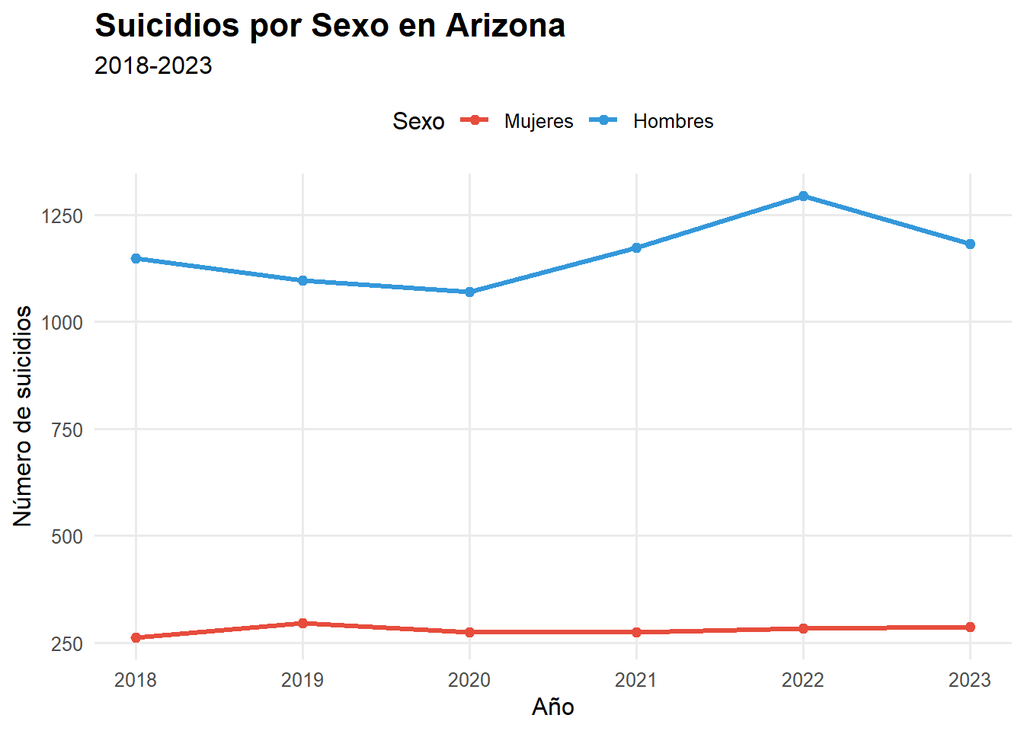

```r
# Crear gráfico
graf_suicHF_ariz <- ggplot(arizona_suic_sexo, aes(x = Year, y = Total_Deaths, color = Sex, group = Sex)) +
  geom_line(size = 1.2) +
  geom_point(size = 2) +
  scale_color_manual(values = c("Males" = "#3498db", "Females" = "#e74c3c"),
                     labels = c("Females" = "Mujeres", "Males" = "Hombres")) +
  labs(title = "Suicidios por Sexo en Arizona",
       subtitle = "2018-2023",
       x = "Año",
       y = "Número de suicidios",
       color = "Sexo") +
  theme_minimal(base_size = 12) +
  theme(plot.title = element_text(face = "bold", size = 16),
        panel.grid.minor = element_blank(),
        legend.position = "top")
print(graf_suicHF_ariz)
```

#### Islandia:

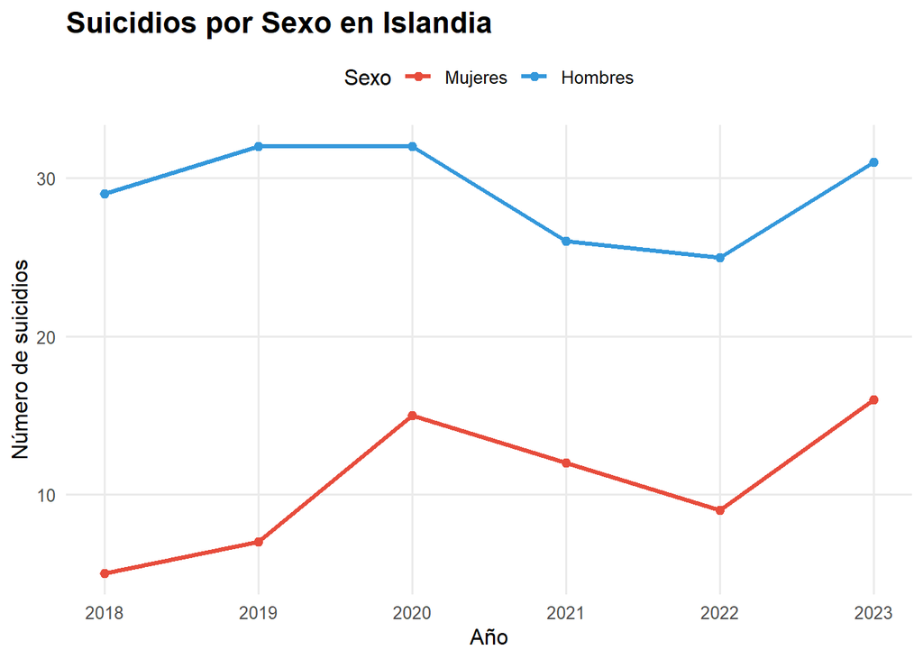

```r
df_clean <- suicidios_Islandia

df_sexo <- suicidios_Islandia %>%
  filter(Age == "Total", Sex != "Total")

graf_suicHF_isl <- ggplot(df_sexo, aes(x = Year, y = value, color = Sex, group = Sex)) +
  geom_line(size = 1.2) +
  geom_point(size = 2) +
  scale_color_manual(values = c("Males" = "#3498db", "Females" = "#e74c3c"),
                     labels = c("Females" = "Mujeres", "Males" = "Hombres")) +
  labs(title = "Suicidios por Sexo en Islandia",
       x = "Año",
       y = "Número de suicidios",
       color = "Sexo") +
  theme_minimal(base_size = 12) +
  theme(plot.title = element_text(face = "bold", size = 16),
        panel.grid.minor = element_blank(),
        legend.position = "top")

print(graf_suicHF_isl)
```

### 2.1.2. Gráficas de temperatura

```r
# Gráfica de temperatura en Arizona
df_temp_arizona <- Arizona_temp_filtrado %>%
  mutate(
    # Crear fecha para extraer mes y estación
    fecha = as.Date(paste(Year, Month, "01", sep = "-")),
    mes = month(fecha, label = TRUE, abbr = FALSE),
    estacion = case_when(
      Month %in% c(12, 1, 2) ~ "Invierno",
      Month %in% c(3, 4, 5) ~ "Primavera",
      Month %in% c(6, 7, 8) ~ "Verano",
      Month %in% c(9, 10, 11) ~ "Otoño"
    )
  )

# Resumen por año y estación
df_resumen_arizona <- df_temp_arizona %>%
  group_by(Year, estacion) %>%
  summarise(
    temp_media = mean(Value, na.rm = TRUE),
    temp_max = max(Value, na.rm = TRUE),
    temp_min = min(Value, na.rm = TRUE)
  ) %>%
  mutate(estacion = factor(estacion, levels = c("Invierno", "Primavera", "Verano", "Otoño")))
```

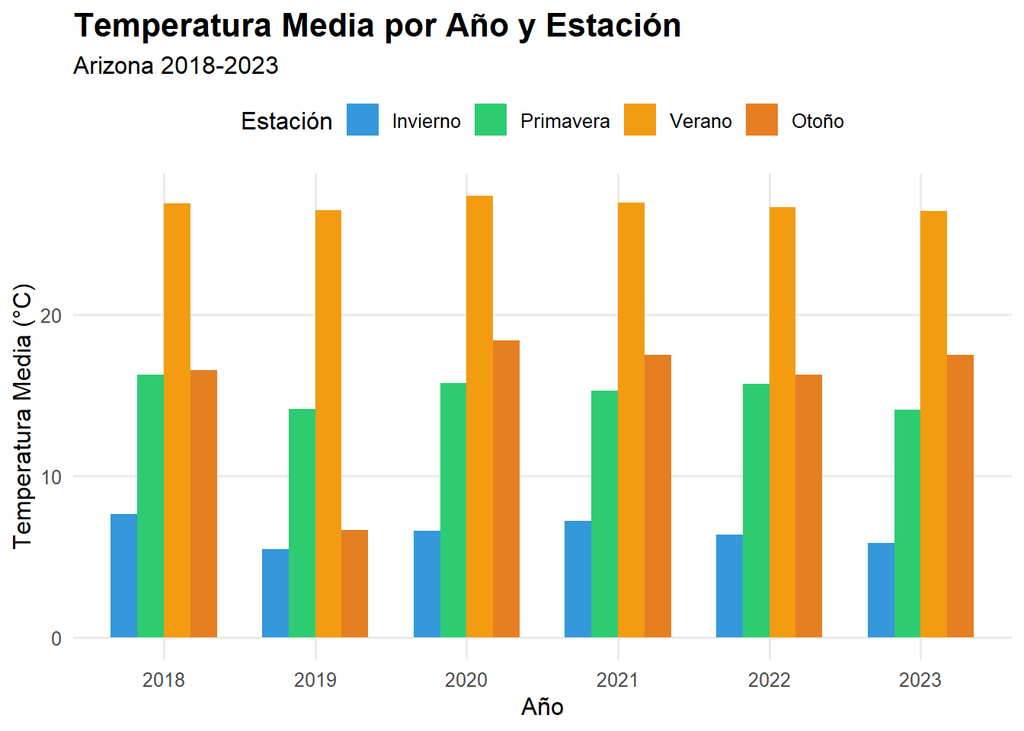

```r
# Gráfico de temperatura
graf_temp_arizona <- ggplot(df_resumen_arizona, aes(x = as.factor(Year), y = temp_media, fill = estacion)) +
  geom_col(position = "dodge", width = 0.7) +
  scale_fill_manual(
    values = c("Invierno" = "#3498db", "Primavera" = "#2ecc71",
               "Verano" = "#f39c12", "Otoño" = "#e67e22")
  ) +
  labs(
    title = "Temperatura Media por Año y Estación",
    subtitle = "Arizona 2018-2023",
    x = "Año",
    y = "Temperatura Media (°C)",
    fill = "Estación"
  ) +
  theme_minimal(base_size = 12) +
  theme(
    plot.title = element_text(face = "bold", size = 16),
    legend.position = "top",
    panel.grid.minor = element_blank()
  )

print(graf_temp_arizona)
```

#### Islandia:

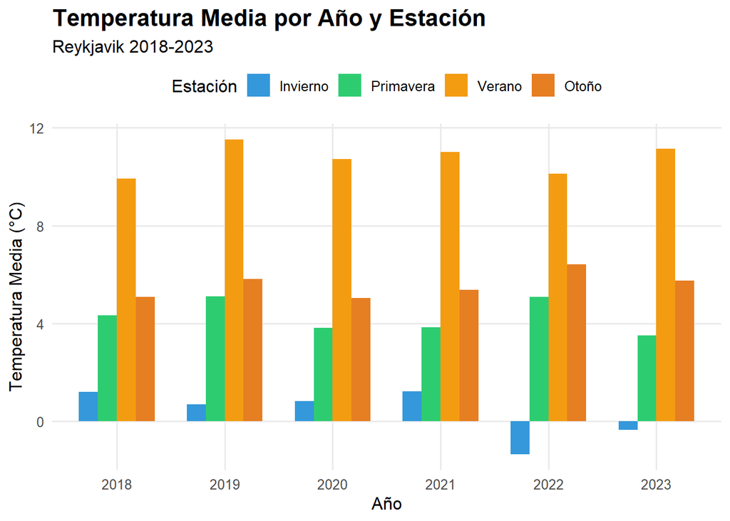

```r
#Grafica de temperatura de Isalandia:
df_temp <- Islandia_temp_json %>%
  spread_all() %>%
  select(fecha, temperatura_media) %>%
  mutate(
    fecha = as.Date(fecha),
    temperatura_media = as.numeric(temperatura_media),
    año = year(fecha),
    mes = month(fecha, label = TRUE, abbr = FALSE),
    mes_num = month(fecha),
    estacion = case_when(
      mes_num %in% c(12, 1, 2) ~ "Invierno",
      mes_num %in% c(3, 4, 5) ~ "Primavera",
      mes_num %in% c(6, 7, 8) ~ "Verano",
      mes_num %in% c(9, 10, 11) ~ "Otoño"
    )
  )

df_resumen <- df_temp %>%
  group_by(año, estacion) %>%
  summarise(
    temp_media = mean(temperatura_media, na.rm = TRUE),
    temp_max = max(temperatura_media, na.rm = TRUE),
    temp_min = min(temperatura_media, na.rm = TRUE),
    .groups = "drop"
  ) %>%
  mutate(estacion = factor(estacion, levels = c("Invierno", "Primavera", "Verano", "Otoño")))

graf_temp_islandia <- ggplot(df_resumen, aes(x = as.factor(año), y = temp_media, fill = estacion)) +
  geom_col(position = "dodge", width = 0.7) +
  scale_fill_manual(
    values = c("Invierno" = "#3498db", "Primavera" = "#2ecc71",
               "Verano" = "#f39c12", "Otoño" = "#e67e22")
  ) +
  labs(
    title = "Temperatura Media por Año y Estación",
    subtitle = "Reykjavik 2018-2023",
    x = "Año",
    y = "Temperatura Media (°C)",
    fill = "Estación"
  ) +
  theme_minimal(base_size = 12) +
  theme(
    plot.title = element_text(face = "bold", size = 16),
    legend.position = "top",
    panel.grid.minor = element_blank()
  )

print(graf_temp_islandia)
```

## 2.2. Gráficas combinadas/comparativas

### 2.2.1. Comparación de Suicidios por Grupos de Edad:

Transformamos los datos de suicidios de Arizona e Islandia para agruparlos en cuatro categorías de edad simplificadas: “0-19”, “20-39”, “40-59” y “60+”. Después, combinamos ambos data frames para generar visualizaciones comparativas.

```r
arizona_edad_simpl <- arizona_suicidios %>%
  filter(
    !is.na(Deaths),
    !is.na(Year),
    Age_Group != "Total",
    Year >= 2018, Year <= 2023
  ) %>%

  # sacamos el primer número de la categoría de edad
  mutate(
    edad_inicio = as.numeric(str_extract(Age_Group, "\\d+")),
    #clasificamos la edad de inicio en 4 grupos.
    Grupo_edad = case_when(
      edad_inicio < 20 ~ "0-19",
      edad_inicio < 40 ~ "20-39",
      edad_inicio < 60 ~ "40-59",
      TRUE            ~ "60+"
    )
  ) %>%
  #eliminamos filas que no tengan una edad de inicio valida
  filter(!is.na(edad_inicio)) %>%
  group_by(Year, Grupo_edad) %>%
  #calculamos el total de muertes por grupo de edad y año.
  summarise(
    Total_Deaths = sum(Deaths, na.rm = TRUE),
    .groups = "drop"
  ) %>%
  mutate(Pais = "Arizona")

# Hacemos lo mismo para Islandia.
islandia_edad_simpl <- suicidios_Islandia %>% # Nota: Usamos 'suicidios_Islandia' del paso 1.3.2.
  filter(
    Age != "Total",
    Sex == "Total",
    Year >= 2018, Year <= 2023,
    !is.na(value)
  ) %>%
  #creamos la columna de edad de inicio y grupo de edad.
  mutate(
    edad_inicio = as.numeric(str_extract(Age, "\\d+")),
    Grupo_edad = case_when(
      edad_inicio < 20 ~ "0-19",
      edad_inicio < 40 ~ "20-39",
      edad_inicio < 60 ~ "40-59",
      TRUE            ~ "60+"
    )
  ) %>%
  # eliminamos filas sin edad de inicio valida.
  filter(!is.na(edad_inicio)) %>%
  group_by(Year, Grupo_edad) %>%
  #calculamos el total de muertes por grupo de edad y año.
  summarise(
    Total_Deaths = sum(value, na.rm = TRUE),
    .groups = "drop" # el drop es para evitar mensajes de agrupamiento.
  ) %>%
  mutate(Pais = "Islandia")

# Unimos ambos data frames para la comparación
comparacion_edad_simpl <- bind_rows(arizona_edad_simpl, islandia_edad_simpl) %>%
  mutate(
    Grupo_edad = factor(Grupo_edad,
                        levels = c("0-19", "20-39", "40-59", "60+"))
  )
```

Generamos una animación para visualizar la evolución anual de los suicidios por grupo de edad, facilitando la comprensión de las tendencias.

```r
library(gganimate)
library(gifski)

# Realizamos la animación con gganimate.
p_anim_edad <- ggplot(
  comparacion_edad_simpl,
  aes(x = Grupo_edad,
      y = Total_Deaths,
      fill = Grupo_edad)
) +
  geom_col(width = 0.7) +
  facet_wrap(~ Pais, scales = "free_y") +   # free_y para que cada país tenga su propia escala y se vea mejor
  labs(
    title = "Suicidios por grupos de edad",
    subtitle = "Año: {closest_state}",
    x = "Grupo de edad",
    y = "Número de suicidios",
    fill = "Grupos de edad"
  ) +
  theme_minimal(base_size = 12) +
  theme(
    plot.title = element_text(face = "bold", size = 16),
    panel.grid.minor = element_blank(),
    legend.position = "bottom"
  ) +
  transition_states(
    Year,
    transition_length = 2,
    state_length = 1
  ) +
  ease_aes("linear")

# Generamos la animacion.
anim_edad <- animate(
  p_anim_edad,
  nframes = 120,
  fps = 6,
  width = 900,
  height = 500,
  renderer = gifski_renderer()
)

anim_edad
# Para guardar la imagen quitar el hastag, pero esque se me guarda cada vez que ejecuto por eso lo comento.
# anim_save("suicidios_grupos_edad_Arizona_Islandia.gif", animation = anim_edad)
```

[output not shown]

A partir de los datos simplificados, generamos un gráfico de líneas para comparar la evolución anual de los suicidios por grupo de edad en Arizona e Islandia.

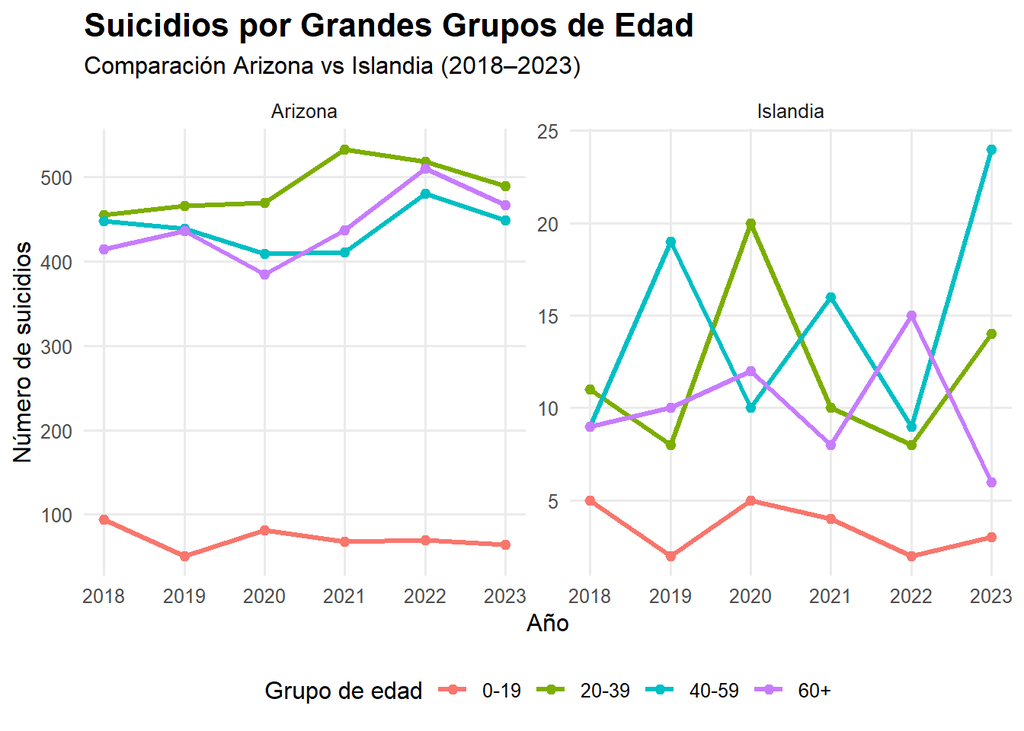

```r
# Hacemos el gráfico comparativo de suicidios por grupo de edad en ambos paises.
graf_comp_edad_simpl <- ggplot(
  comparacion_edad_simpl,
  aes(x = Year, y = Total_Deaths,
      color = Grupo_edad, group = Grupo_edad)
) +
  geom_line(size = 1.2) +
  geom_point(size = 2) +
  facet_wrap(~ Pais, scales = "free_y") +   # escala libre por país
  labs(
    title = "Suicidios por Grandes Grupos de Edad",
    subtitle = "Comparación Arizona vs Islandia (2018–2023)",
    x = "Año",
    y = "Número de suicidios",
    color = "Grupo de edad"
  ) +
  theme_minimal(base_size = 12) +
  theme(
    plot.title = element_text(face = "bold", size = 16),
    panel.grid.minor = element_blank(),
    legend.position = "bottom"
  )

print(graf_comp_edad_simpl) #grafico de suicidios por grupo de edad en los dos sitios
```

### Analisis de correlacion entre temperatura y suicidios en Arizona e Islandia:

```r
# Suicidios totales por año en Arizona

arizona_suic_anual <- arizona_suicidios %>%
filter(Year >= 2018, Year <= 2023,
!is.na(Deaths)) %>%
group_by(Year) %>%
summarise(
suicidios_totales = sum(Deaths, na.rm = TRUE),
.groups = "drop"
)

# Temperatura media anual en Arizona (a partir de df_temp_arizona creado antes)

arizona_temp_anual <- Arizona_temp_filtrado %>%
  group_by(Year) %>%
  summarise(
    temp_media_anual = mean(Value, na.rm = TRUE),
    .groups = "drop"
  )

# Unimos temperatura y suicidios

arizona_temp_suic <- inner_join(
arizona_temp_anual,
arizona_suic_anual,
by = "Year"
)

arizona_temp_suic
```

```
## # A tibble: 6 × 3
##    Year temp_media_anual suicidios_totales
##   <dbl>            <dbl>             <dbl>
## 1  2018             16.8              1411
## 2  2019             13.2              1392
## 3  2020             17.0              1344
## 4  2021             16.7              1449
## 5  2022             16.2              1578
## 6  2023             16.0              1469
```

[figure not shown]

```r
# Diagrama de dispersión con recta de regresión

graf_arizona_temp_suic <- ggplot(arizona_temp_suic,
aes(x = temp_media_anual,
y = suicidios_totales)) +
geom_point(size = 3) +
geom_smooth(method = "lm", se = FALSE) +
labs(
title = "Arizona: suicidios vs temperatura media anual",
subtitle = "2018–2023",
x = "Temperatura media anual (°F)",
y = "Número de suicidios"
) +
theme_minimal(base_size = 12)

print(graf_arizona_temp_suic)
```

```r
# Coeficiente de correlación de Pearson

cor_arizona <- cor(
arizona_temp_suic$temp_media_anual,
arizona_temp_suic$suicidios_totales,
use = "complete.obs"
)
cor_arizona
```

```
## [1] 0.09203191
```

```r
# Suicidios totales por año en Islandia (usando suicidios_Islandia)

islandia_suic_anual <- suicidios_Islandia %>%
filter(Year >= 2018, Year <= 2023,
Sex == "Total",
!is.na(value)) %>%
group_by(Year) %>%
summarise(
suicidios_totales = sum(value, na.rm = TRUE),
.groups = "drop"
)

# Temperatura media anual en Islandia (a partir de df_temp creado antes)

islandia_temp_anual <- df_temp %>%
group_by(año) %>%
summarise(
temp_media_anual = mean(temperatura_media, na.rm = TRUE),
.groups = "drop"
) %>%
rename(Year = año)

# Unimos temperatura y suicidios

islandia_temp_suic <- inner_join(
islandia_temp_anual,
islandia_suic_anual,
by = "Year"
)

islandia_temp_suic
```

```
## # A tibble: 6 × 3
##    Year temp_media_anual suicidios_totales
##   <dbl>            <dbl>             <int>
## 1  2018             5.15                68
## 2  2019             5.81                78
## 3  2020             5.11                94
## 4  2021             5.38                76
## 5  2022             5.10                68
## 6  2023             5.04                94
```

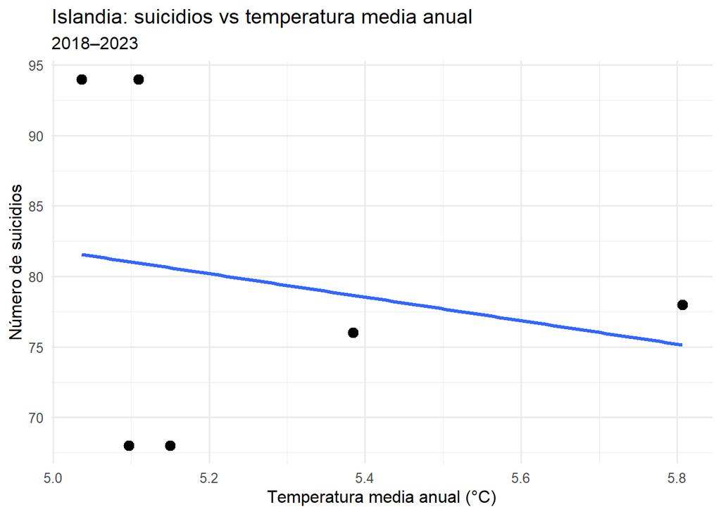

```r
# Diagrama de dispersión con recta de regresión

graf_islandia_temp_suic <- ggplot(islandia_temp_suic,
aes(x = temp_media_anual,
y = suicidios_totales)) +
geom_point(size = 3) +
geom_smooth(method = "lm", se = FALSE) +
labs(
title = "Islandia: suicidios vs temperatura media anual",
subtitle = "2018–2023",
x = "Temperatura media anual (°C)",
y = "Número de suicidios"
) +
theme_minimal(base_size = 12)

print(graf_islandia_temp_suic)
```

```r
# Coeficiente de correlación de Pearson

cor_islandia <- cor(
islandia_temp_suic$temp_media_anual,
islandia_temp_suic$suicidios_totales,
use = "complete.obs"
)
cor_islandia
```

```
## [1] -0.2054854
```

En Islandia el coeficiente de correlación también es bajo y no significativo y, además, es negativo, por lo que, al igual que en Arizona, no se evidencia una relación lineal fuerte entre temperatura media anual y número de suicidios en el periodo 2018–2023.